# Gibbs sampling for Bayesian Binary Probit

## 0.3 Bayesian Binary Probit Regression

Instead of computing just the MLE estimate of the model parameters, we can go further and compute their posterior distribution by taking a Bayesian approach. We can complete the Bayesian model by taking a prior distribution $\pi(\boldsymbol{\theta})$ over the model parameters. Then the Bayesian binary probit regression model becomes,

$$\begin{aligned}\label{probit-regression-eq}
y_{i} & \sim \mathcal{B}ernoulli\Big(\Phi(\eta_{i})\Big) \\
\eta_{i} & = \boldsymbol{x}_{i} \boldsymbol{\theta} \\
\boldsymbol{\theta} & \sim \pi(\boldsymbol{\theta})
\end{aligned}$$

and the graphical model can be represented in the following way,

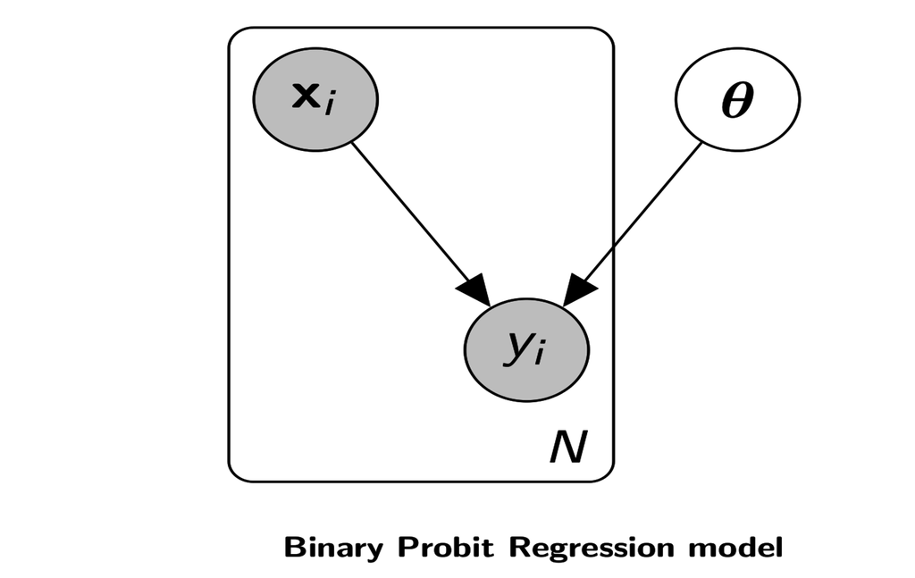

The posterior distribution for the Bayesian binary probit model is the following,
$$\begin{aligned}
p(\boldsymbol{\theta} | \boldsymbol{y}, \boldsymbol{X}) & \propto p(\boldsymbol{\theta}) p(\boldsymbol{y} | \boldsymbol{\theta}, \boldsymbol{X}) = \pi(\boldsymbol{\theta}) \prod\limits_{i=1}^{N} p(y_{i} | \boldsymbol{\theta}, \boldsymbol{x}_{i}) \\
& = \pi(\boldsymbol{\theta}) \prod\limits_{i=1}^{N} \Phi\Big(\boldsymbol{x}_{i} \boldsymbol{\theta}\Big)^{y_{i}} \Big(1 - \Phi(\boldsymbol{x}_{i} \boldsymbol{\theta})\Big)^{(1 - y_{i})}
\end{aligned}$$

Performing inference for this model in the Bayesian framework is complicated by the fact that no conjugate prior $\pi(\boldsymbol{\theta})$ exists for the parameters of the probit regression model. To overcome this problem, [Albert and Chib (1993)](http://www.tandfonline.com/doi/abs/10.1080/01621459.1993.10476321) augmented the original model with an additional auxiliary variable that renders the conditional distributions of the model parameters equivalent to those under a Bayesian normal linear regression model with Gaussian noise; and derived an efficient Gibbs sampling scheme for computing the posterior statistics.

### 0.3.1 Augmented Model

Let us introduce $N$ independent latent variables $z_{i}$, where each $z_{i}$ follows a normal distribution. Then the augmented probit model has the following hierarchical structure,

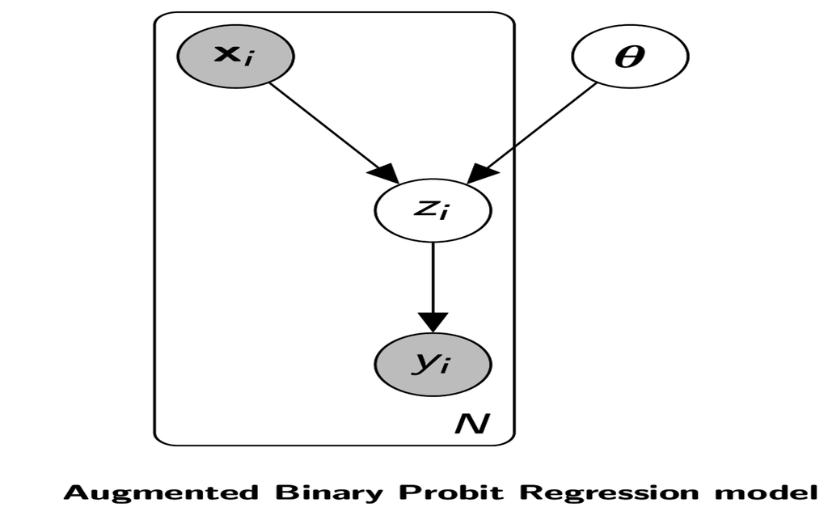

where,

$$\begin{aligned}
y_{i} & = \begin{cases}
1 & \; \text{if } z_{i} > 0\\
0 & \; \text{if } z_{i} \leq 0\\
\end{cases} \nonumber \\
z_{i} & = \boldsymbol{x}_{i} \boldsymbol{\theta} + \epsilon_{i} \\
\epsilon_{i} & \sim \mathcal{N}(0,1) \nonumber \\
\boldsymbol{\theta} & \sim \pi(\boldsymbol{\theta}) \nonumber
\end{aligned}$$

where $y_{i}$ is now deterministic conditional on the sign of the stochastic auxiliary variable $z_{i}$. Therefore we formulate the original problem as a missing data problem where we have a normal regression model on the latent data $z_{i}$ and the observed responses $y_{i}$ are incomplete in that we only observe whether $z_{i} > 0$ or $z_{i} \leq 0$.

We are interested in computing the joint posterior distribution of the latent variables $\boldsymbol{z}$ and the model parameters $\boldsymbol{\theta}$ given the data $\boldsymbol{y}$ and $\boldsymbol{X}$,

$$\begin{aligned}
p(\boldsymbol{z}, \boldsymbol{\theta} | \boldsymbol{y}, \boldsymbol{X}) \propto p(\boldsymbol{\theta}) p(\boldsymbol{z}|\boldsymbol{\theta}, \boldsymbol{X}) p(\boldsymbol{y}| \boldsymbol{z})
= \pi(\boldsymbol{\theta}) \prod\limits_{i=1}^{N} p(z_{i}| \boldsymbol{\theta}, \boldsymbol{x}_{i}) p(y_{i}| z_{i})
\end{aligned}$$

where we have that,

$$\begin{aligned}
p(z_{i}| \boldsymbol{\theta}, \boldsymbol{x}_{i}) & = \mathcal{N}(z_{i} | \boldsymbol{x}_{i} \boldsymbol{\theta}, 1) \nonumber\\
p(y_{i}| z_{i}) & = \boldsymbol{1}(y_{i} = 1)\boldsymbol{1}(z_{i} > 0) + \boldsymbol{1}(y_{i} = 0)\boldsymbol{1}(z_{i} \leq 0)
\end{aligned}$$
where $\boldsymbol{1}(\cdot)$ is the indicator function, equal to $1$ if the quantities inside the function are satisfied, and $0$ otherwise.

### 0.3.2 Gibbs sampling scheme

This joint posterior is difficult to normalize and sample from directly. However, computation of the marginal posterior of $\boldsymbol{\theta}$ and $\boldsymbol{z}$ using the Gibbs sampling requires only computing $p(\boldsymbol{\theta} | \boldsymbol{z}, \boldsymbol{y}, \boldsymbol{X})$ and $p(\boldsymbol{z} | \boldsymbol{\theta}, \boldsymbol{y}, \boldsymbol{X})$, and these full conditional distributions are of standard forms. It should be noted that $p(\boldsymbol{\theta} | \boldsymbol{z}, \boldsymbol{y}, \boldsymbol{X}) = p(\boldsymbol{\theta} | \boldsymbol{z}, \boldsymbol{X})$, since $\boldsymbol{\theta}$ is conditionally independent of $\boldsymbol{y}$ given $\boldsymbol{z}$.

First, the full conditional of $\boldsymbol{\theta}$ is given by,

$$p(\boldsymbol{\theta} | \boldsymbol{z}, \boldsymbol{X}) \propto \pi(\boldsymbol{\theta}) \prod\limits_{i=1}^{N} \mathcal{N}(z_{i} | \boldsymbol{x}_{i} \boldsymbol{\theta}, 1)$$

This quantity is the posterior density for the normal linear regression model. Using standard linear model results, if we use a constant prior for $\boldsymbol{\theta}$, i.e. $\pi(\boldsymbol{\theta}) \propto 1$, then,

$$\boldsymbol{\theta} | \boldsymbol{z}, \boldsymbol{X} \sim \mathcal{N}\Big((\boldsymbol{X}^{T}\boldsymbol{X})^{-1}\boldsymbol{X}^{T}\boldsymbol{z}, (\boldsymbol{X}^{T}\boldsymbol{X})^{-1}\Big)$$

However, if we assign the proper conjugate prior $\pi(\boldsymbol{\theta}) = \mathcal{N}(\boldsymbol{\theta}_{0}, \boldsymbol{Q}_{0})$, then,

$$\begin{aligned}
\boldsymbol{\theta} | \boldsymbol{z}, \boldsymbol{X} & \sim \mathcal{N}(\boldsymbol{M}, \boldsymbol{V}) \\
\boldsymbol{M} & = \boldsymbol{V} (\boldsymbol{Q}_{0}^{-1}\boldsymbol{\theta}_{0} + \boldsymbol{X}^{T}\boldsymbol{z}) \\
\boldsymbol{V} & = (\boldsymbol{Q}_{0}^{-1} + \boldsymbol{X}^{T}\boldsymbol{X})^{-1}
\end{aligned}$$

Now suppose we knew $\boldsymbol{\theta}$. Then we could easily draw the latent variables $z_{i}$ from their distribution conditional on $\boldsymbol{\theta}$ and $\boldsymbol{x}_{i}$, which is $\mathcal{N}(\boldsymbol{x}_{i}\boldsymbol{\theta},1)$. However, if we also condition on the $y_{i}$, we need to take into consideration this additional source of information. Thus, the full conditional of $z_{i} | \boldsymbol{\theta}, y_{i}, \boldsymbol{x}_{i}$ is a truncated normal distribution,

$$z_{i} | \boldsymbol{\theta}, y_{i}, \boldsymbol{x}_{i} \sim \begin{cases}
\mathcal{TN}(\boldsymbol{x}_{i}\boldsymbol{\theta}, 1, 0, \infty) & \; \text{if } y_{i} = 1\\
\mathcal{TN}(\boldsymbol{x}_{i}\boldsymbol{\theta}, 1, -\infty, 0) & \; \text{if } y_{i} = 0\\
\end{cases}$$

### 0.3.3 Gibbs sampling implementation

Gibbs sampling is an MCMC algorithm that simulates draws (i.e. Monte Carlo) that are dependent (i.e. Markov Chain), and these draws are approximately from the probability distribution of interest, i.e. the target distribution $p(\boldsymbol{z}, \boldsymbol{\theta} | \boldsymbol{y}, \boldsymbol{X})$.

In each simulation step of the Gibbs algorithm we have to sample $\boldsymbol{\theta} | \boldsymbol{z}, \boldsymbol{X}$ and $z_{i} | \boldsymbol{\theta}, y_{i}, \boldsymbol{x}_{i}$ in turn. The following code implements the Gibbs sampling algorithm for the Bayesian binary probit model.

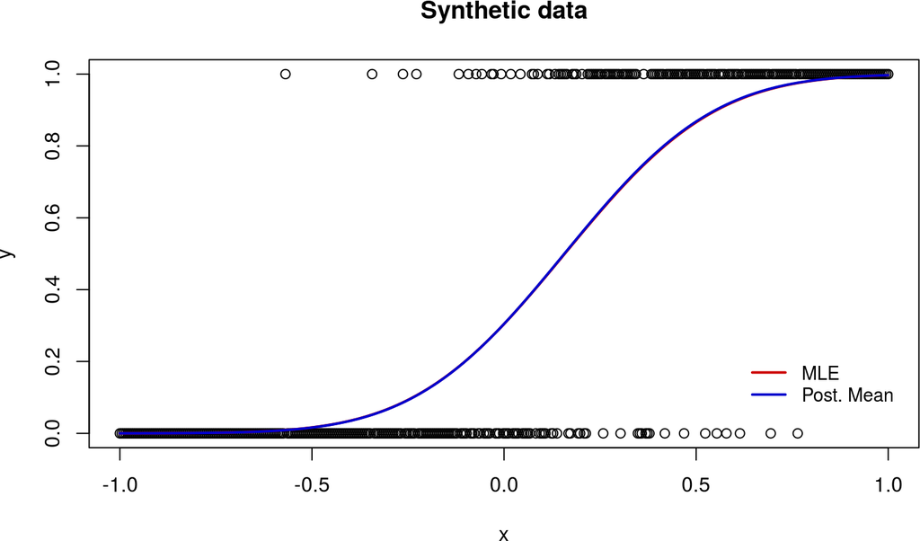

```r
# Library for sampling from Multivariate Normal distribution
require(mvtnorm)
# Library for sampling from Truncated Normal distribution
require(truncnorm)


# Conjugate prior on the coefficients \theta ~ N(theta_0, Q_0)
theta_0 <- rep(0, D)
Q_0 <- diag(10, D)

# Initialize parameters
theta <- rep(0, D)
z <- rep(0, N)

# Number of simulations for Gibbs sampler
N_sim <- 10000
# Burn in period
burn_in <- 5000
# Matrix storing samples of the \theta parameter
theta_chain <- matrix(0, nrow = N_sim, ncol = D)


# ---------------------------------
# Gibbs sampling algorithm
# ---------------------------------

# Compute posterior variance of theta
prec_0 <- solve(Q_0)
V <- solve(prec_0 + crossprod(X, X))

for (t in 2:N_sim) {
  # Update Mean of z
  mu_z <- X %*% theta
  # Draw latent variable z from its full conditional: z | \theta, y, X
  z[y == 0] <- rtruncnorm(N0, mean = mu_z[y == 0], sd = 1, a = -Inf, b = 0)
  z[y == 1] <- rtruncnorm(N1, mean = mu_z[y == 1], sd = 1, a = 0, b = Inf)

  # Compute posterior mean of theta
  M <- V %*% (prec_0 %*% theta_0 + crossprod(X, z))
  # Draw variable \theta from its full conditional: \theta | z, X
  theta <- c(rmvnorm(1, M, V))

  # Store the \theta draws
  theta_chain[t, ] <- theta
}

# ---------------------------
# Get posterior mean of \theta
# ---------------------------
# (Intercept)           x
#  -0.5026835   3.2076024
post_theta <- colMeans(theta_chain[-(1:burn_in), ])

# Plot covariates x versus observations y
plot(x, y, main = "Synthetic data")
# Show the fitted function using the posterior mean estimates
lines(x = x, y = pnorm(X %*% mle_theta), col = "red3", lwd = 2)
lines(x = x, y = pnorm(X %*% post_theta), col = "blue3", lwd = 2)
legend("bottomright", legend=c("MLE","Post. Mean"), col=c("red3","blue3"),
       bty = 'n', lwd = 2, inset = c(0.02, 0.08), lty = 1, cex = 0.9)
```

Having stored the information of each MCMC iteration in the `theta_chain` matrix, we can create some useful plots to obsevere how the chain evolved over each iteration and how the marginal density plot of each parameter looks like. In the figure below, the top panel depicts the marginal histogram of the sampled values over all the iterations after the burn-in period, and the bottom panel shows the trace plot of each parameter, i.e. the values the parameters took during the runtime of the MCMC simulation. As we observe, after only a few hundred iteration steps the MCMC chain converged to the true values of the parameters. The $red$ line corresponds to the true parameter values, the $gold$ line to the posterior mean of the MCMC chain, and the $green$ line to the MLE estimate.

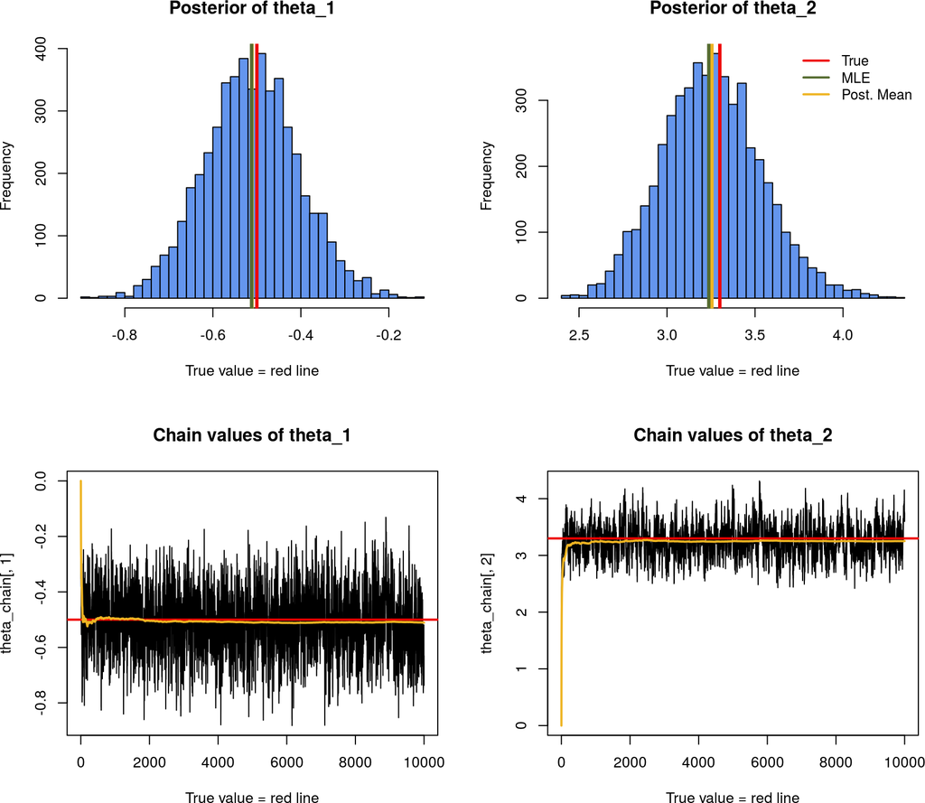

```r
par(mfrow = c(2,2))
hist(theta_chain[-(1:burn_in),1],breaks=30, main="Posterior of theta_1",
     xlab="True value = red line", col="cornflowerblue")
abline(v = post_theta[1], col="goldenrod2", lwd=3)
abline(v = true_theta[1], col="red2", lwd=3)
abline(v = mle_theta[1], col="darkolivegreen", lwd=3)
hist(theta_chain[-(1:burn_in),2], breaks=30, main="Posterior of theta_2",
     xlab="True value = red line", col="cornflowerblue")
abline(v = post_theta[2], col="goldenrod2", lwd=3)
abline(v = true_theta[2], col="red2", lwd=3)
abline(v = mle_theta[2], col="darkolivegreen", lwd=3)
legend("topright", c("True", "MLE", "Post. Mean"), lty=1, lwd=2,
       col=c("red2", "darkolivegreen","goldenrod2"), bty='n', cex=.95)

plot(theta_chain[, 1], type = "l", xlab="True value = red line" ,
     main = "Chain values of theta_1")
abline(h = true_theta[1], col="red2", lwd=2)
lines(cumsum(theta_chain[, 1])/(1:N_sim), col="goldenrod2", lwd=2)
plot(theta_chain[, 2], type = "l", xlab="True value = red line" ,
     main = "Chain values of theta_2")
abline(h = true_theta[2], col="red2", lwd=2)
lines(cumsum(theta_chain[, 2])/(1:N_sim), col="goldenrod2", lwd=2)
```